# The Department of Defense and its Correspondence Relationship with Legislators

PS 699: Independent Study (Spring 2020)

Fatima Ali

# Introduction

# Literature Review

# Theory

# Why is the DOD Important to Study?

# Data and Data Collection

Altogether we have 7635 letters received by the Department of Defense that are marked as “congressional” from 2007-2017. All of these letters are from Members of the U.S. Congress. Note: During my independent study, I handcoded approzimately 3,492 letters from a variety of Department of Defense agencise. Unfortunately, we were not able to implement these observations into the final data set. Thus, observations that are missing a Policy Type Category have a current Type of NA.

# A Potential Outlier

In this analysis, Senator Grassley (R-IA) is considered to be an outlier. He wrote 188 letters to the Department of Defense, the most out of any other members of congress. However, he was never a part of any committee that actively work for the Department of Defense. Although at this point, we are unable to see what are the policy categories of the letters he wrote to the Department of Defense, based off of the hand-coding I did, Grassley wrote a majority of his letters on behalf of constituents, specifically for Veterans in Iowa. On further analysis, Grassley’s campaign has largely been based on providing veterans in Iowa opportunities to present their legacy to other residents in Iowa and the US, and more within the realm of congressional agencies, aid with ensuring that veterans receive their benefits after retiring or being discharged from the military. These benefits include disability compensation, education programs, health benefits, and more. A majority of these concerns would be best addressed via the Department of Veteran Affairs versus most of the Department of Defense agencies, however, many of the issues, such as Military Pay complaints as well as sexual harrassment allegations can indeed be addressed with the Department of Defense agencies, such as the Department of Defense and Accounting Service (DFAS) as well as the Office of the Inspector General, U.S. Department of Defense (DOD_OIG). Thus, at this time, I am not considering Senator Grassley to be an outlier in my analysis.

Top Policy Categories within Grassley’s Letters to the DOD

| bioname | party | TYPE | cqlabel | n |
| --- | --- | --- | --- | --- |
| GRASSLEY, Charles Ernest | (R) | NA | (IA) | 168 |
| GRASSLEY, Charles Ernest | (R) | 1 | (IA) | 19 |
| GRASSLEY, Charles Ernest | (R) | 5 | (IA) | 1 |

# Top 10 Legislators who wrote the most letters to the DOD

Except for Senator Grassley, many of the legislators who most frequently wrote letters to the DOD were either Veterans and/or members of the Armed Services committee or the Appropriations committee. At this moment, a majority of the letters written by the top legislators are letters written on behalf of constituents. As new observations are implemented, I expect constituent letters to still be the highest, but I expect policy/oversight letters as well as letters on behalf of businesses to slowly trickle in due to the logs we have from the DOD_USACE agency as well as the DOD_OIG/DOD_OSDJS agencies.

Legislators who wrote the most letters to DOD

| bioname | party | chamber | cqlabel | committees | n |
| --- | --- | --- | --- | --- | --- |
| GRASSLEY, Charles Ernest | (R) | Senate | (IA) | AGRICULTURE\|BUDGET\|FINANCE\|JUDICIARY\|TAXATION | 187 |
| FORBES, J. Randy | (R) | House | (VA-04) | ARMED SERVICES\|JUDICIARY | 86 |
| McCAIN, John Sidney, III | (R) | Senate | (AZ) | ARMED SERVICES\|HOMELAND SECURITY\|INDIAN | 72 |
| NELSON, Clarence William (Bill) | (D) | Senate | (FL) | ARMED SERVICES\|COMMERCE\|FINANCE\|AGING | 64 |
| HUNTER, Duncan Duane | (R) | House | (CA-50) | ARMED SERVICES\|EDUCATION\|TRANSPORTATION | 59 |
| PELOSI, Nancy | (D) | House | (CA-08) | SPEAKER | 59 |
| McCASKILL, Claire | (D) | Senate | (MO) | ARMED SERVICES\|COMMERCE\|HOMELAND SECURITY\|AGING | 58 |
| OBEY, David Ross | (D) | House | (WI-07) | APPROPRIATIONS | 57 |
| WOLF, Frank Rudolph | (R) | House | (VA-10) | APPROPRIATIONS | 57 |
| WITTMAN, Robert J. | (R) | House | (VA-01) | ARMED SERVICES\|NATURAL RESOURCES | 55 |

Policy Categories within Legislators’ Letters to the DOD

| bioname | party | chamber | TYPE | cqlabel | committees | n |
| --- | --- | --- | --- | --- | --- | --- |
| GRASSLEY, Charles Ernest | (R) | Senate | NA | (IA) | AGRICULTURE\|BUDGET\|FINANCE\|JUDICIARY\|TAXATION | 167 |
| FORBES, J. Randy | (R) | House | NA | (VA-04) | ARMED SERVICES\|JUDICIARY | 58 |
| WEBB, James H. (Jim) | (D) | Senate | NA | (VA) | ARMED SERVICES\|FOREIGN RELATIONS\|VETERANS\|ECONOMIC | 45 |
| McCASKILL, Claire | (D) | Senate | NA | (MO) | ARMED SERVICES\|COMMERCE\|HOMELAND SECURITY\|AGING | 43 |
| NELSON, Clarence William (Bill) | (D) | Senate | 1 | (FL) | ARMED SERVICES\|COMMERCE\|FINANCE\|AGING | 43 |
| PELOSI, Nancy | (D) | House | 6 | (CA-08) | SPEAKER | 43 |
| BOOZMAN, John | (R) | Senate | 1 | (AR) | AGRICULTURE\|APPROPRIATIONS\|ENVIRONMENT\|RULES\|VETERANS | 37 |
| OBEY, David Ross | (D) | House | 6 | (WI-07) | APPROPRIATIONS | 36 |
| TOOMEY, Patrick Joseph | (R) | Senate | 1 | (PA) | BANKING\|BUDGET\|FINANCE | 33 |
| GRAHAM, Lindsey O. | (R) | Senate | 1 | (SC) | APPROPRIATIONS\|ARMED SERVICES\|BUDGET\|JUDICIARY | 32 |
| WOLF, Frank Rudolph | (R) | House | 1 | (VA-10) | APPROPRIATIONS | 32 |

Most Common Policy Areas

| TYPE | n |
| --- | --- |
| 1 | 3798 |
| 5 | 149 |
| 6 | 88 |
| 0 | 43 |
| 2 | 35 |
| 3 | 25 |
| 4 | 3 |

## 114th Congress

According to the diagram below, currently, our data set shows that a majority of letters have been written on behalf of constituent issues. However, the 114th congress has 3722 letters. This the most amount of letters received by the DOD during a congressional term. One reason why this result may be showing at the moment is because a majority of the logs we have received from the DOD are from the 114th congress (January 2015-January 2017). Another reason why there is a large influx of letters from the 114th congress is because there were numerous scandals that were unraveled, mainly scandals regarding sexual assault and deficiencies with veterans receiving theirn health and discharge records. The tables below show that a majority of letters were written to the DOD with issues during the constituent’s time in service, mainly issues that have the subject lines of pay during their enlistment or the process of being discharged and collecting their records afterwards.

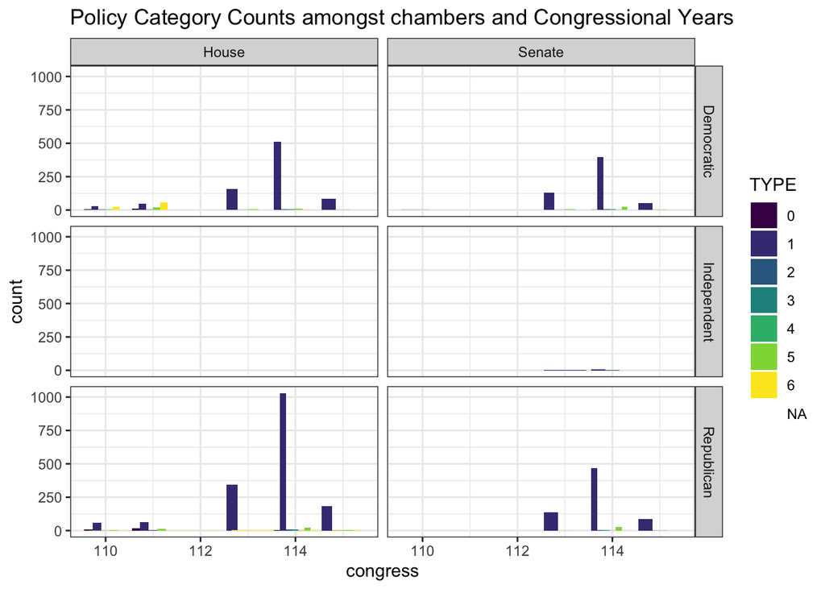

```r
d %>%
  ggplot() +
  aes(x = congress, fill = TYPE) +
  geom_bar(position = "dodge") +
  facet_grid(party_name ~ chamber) +
  labs(title = "Policy Category Counts amongst chambers and Congressional Years")
```

```r
d %>% count(congress,sort = T) %>% top_n(10, n) %>% kable(caption = "Letters from Each Congressional session")
```

Letters from Each Congressional session

| congress | n |
| --- | --- |
| 114 | 3722 |
| 113 | 1384 |
| 111 | 704 |
| 115 | 700 |
| 110 | 682 |
| 112 | 443 |

```r
d %>% filter(str_detect(congress, "114")) %>% count(bioname,party, cqlabel, committees, sort = T) %>% top_n(10, n) %>% kable(caption = "Top 10 Legislators who wrote letters in 114th Congress")
```

Top 10 Legislators who wrote letters in 114th Congress

| bioname | party | cqlabel | committees | n |
| --- | --- | --- | --- | --- |
| McCAIN, John Sidney, III | (R) | (AZ) | ARMED SERVICES\|HOMELAND SECURITY\|INDIAN | 60 |
| NELSON, Clarence William (Bill) | (D) | (FL) | ARMED SERVICES\|COMMERCE\|FINANCE\|AGING | 60 |
| GRASSLEY, Charles Ernest | (R) | (IA) | AGRICULTURE\|BUDGET\|FINANCE\|JUDICIARY\|TAXATION | 53 |
| HUNTER, Duncan Duane | (R) | (CA-50) | ARMED SERVICES\|EDUCATION\|TRANSPORTATION | 51 |
| BOOZMAN, John | (R) | (AR) | AGRICULTURE\|APPROPRIATIONS\|ENVIRONMENT\|RULES\|VETERANS | 44 |
| BURR, Richard M. | (R) | (NC) | FINANCE\|HEALTH\|INTELLIGENCE | 42 |
| TOOMEY, Patrick Joseph | (R) | (PA) | BANKING\|BUDGET\|FINANCE | 41 |
| FORBES, J. Randy | (R) | (VA-04) | ARMED SERVICES\|JUDICIARY | 39 |
| MURRAY, Patty | (D) | (WA) | APPROPRIATIONS\|BUDGET\|HEALTH\|VETERANS | 36 |
| RUBIO, Marco | (R) | (FL) | COMMERCE\|FOREIGN RELATIONS\|SMALL BUSINESS\|INTELLIGENCE | 35 |

```r
d %>% filter(str_detect(congress, "114")) %>% count(SUBJECT, agency, sort = T) %>% top_n(10, n) %>% kable(caption = "Top 10 Subjects of Letters sent to DOD in 114th Congress")
```

Top 10 Subjects of Letters sent to DOD in 114th Congress

| SUBJECT | agency | n |
| --- | --- | --- |
| #NAME? | DOD_Navy | 322 |
| MILITARY PAY - ARMY, AIRFORCE | DOD_DFAS | 191 |
| NA | DOD_OIG | 134 |
| - REQUEST FOR UPGRADE OF DISCHARGE - | DOD_Navy | 45 |
| - DESIRE TO ENLIST - | DOD_Navy | 44 |
| - REQUEST FOR CORRECTION OF RECORDS - | DOD_Navy | 34 |
| - DISCHARGE UPGRADE REQUEST - | DOD_Navy | 27 |
| 8 SENATORS CONCERED ABOUT THE CONVERSION OF DeCA EMPLOYEES | DOD_DeCA | 27 |
| - REQUEST TO ENLIST INTO THE NAVY - | DOD_Navy | 26 |
| - EMPLOYMENT CONCERNS - | DOD_Navy | 24 |

# Senators Versus State Population for all Agencies

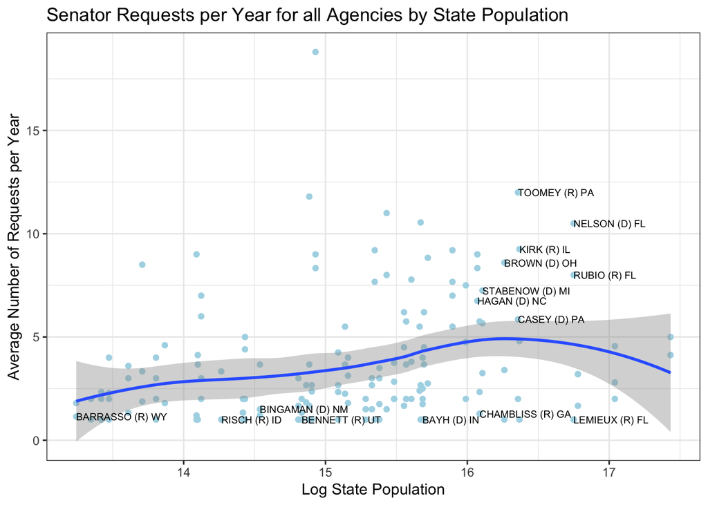

# Senators Versus State Population for DOD

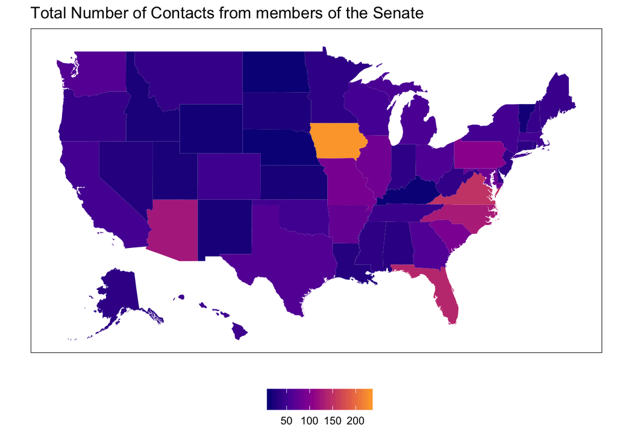

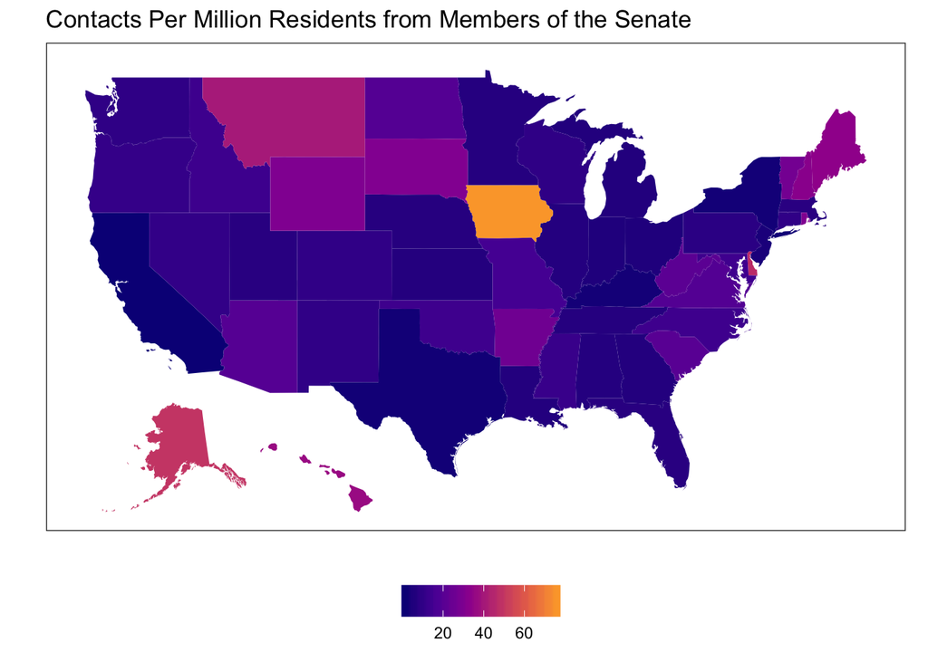

# Senators versus Veteran Population

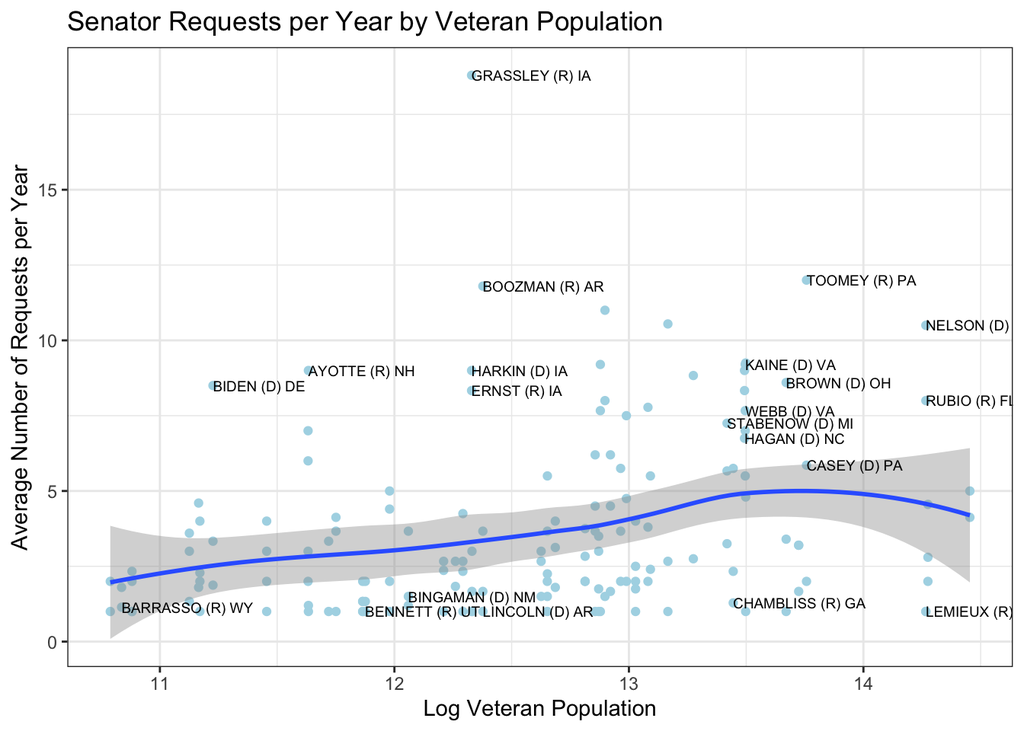

[figure not shown]

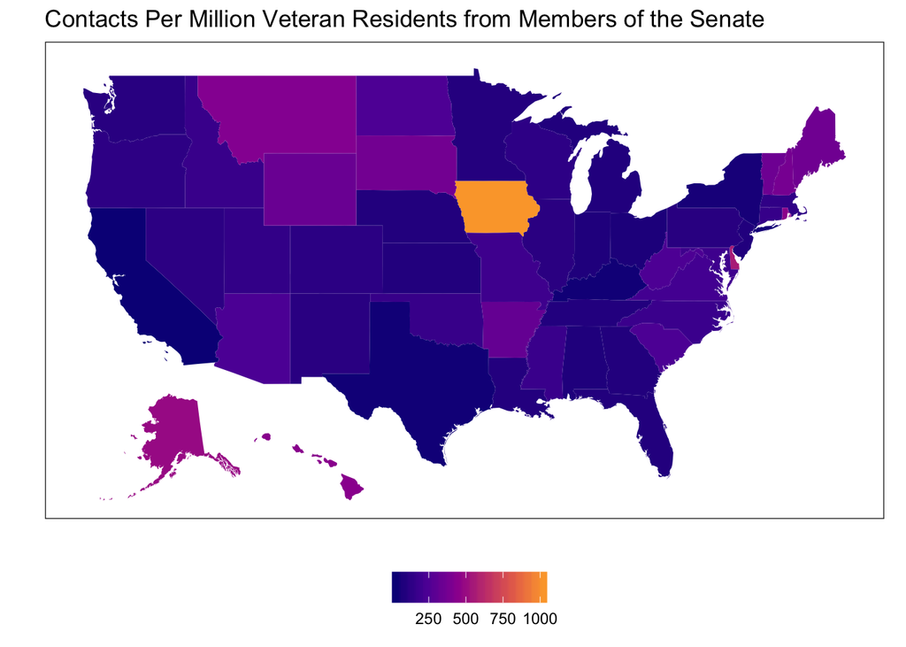

# Members who contact DOD more than average

The following panels show members of congress who contact the DOD more than average. The top panel shows the Senators who wrote the most letters to the DOD and the bottom panel shows the Representatives who wrote the most letters to the DOD. The hash mark represents the legislator that wrote a letter on that date. It is important to note that many members listed in the table weren’t in the chamber for the entire period, so blank stretches at the end or beginning of the line may possibly indicate that the member of congress was out of office during that time period. Note that Chuck Grassley wrote the most letters to the DOD amongst all members of the Senate. It is also important to note that there was a large increase in letters written to congress from 2016-2018. This is mainly due to the fact that were a huge amount of scandals that were discovered within the DOD, especially regarding military pay and the treatment of civlians and soldiers in hospitals in Afghanistan.

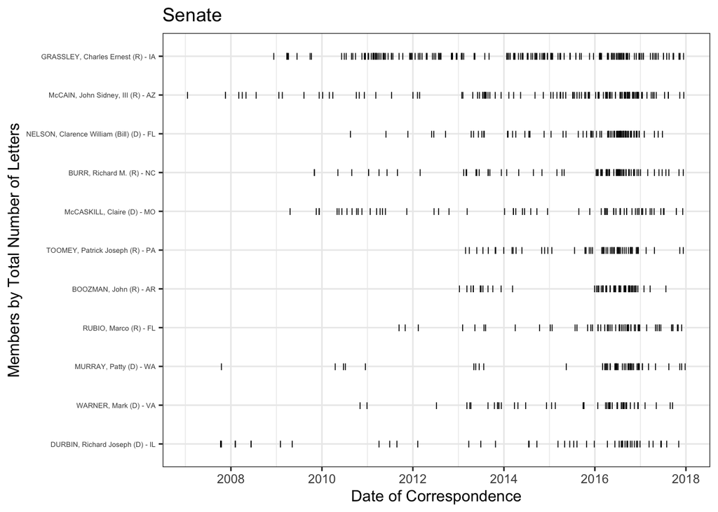

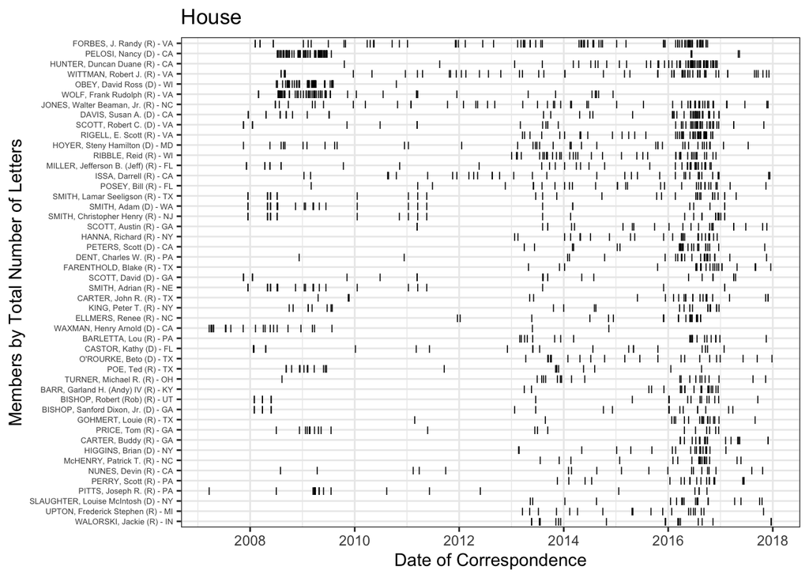

# Are letters to the DOD Cosigned?

This section shows a rough under-estimate based off of whether “et al” or “&” appears in the summary.

The first figure shows the amount of letters that are cosigned in all the federal agencies that we currently have data for. There aren’t many letters that are cosigned, but there are still a notable amount in all years.

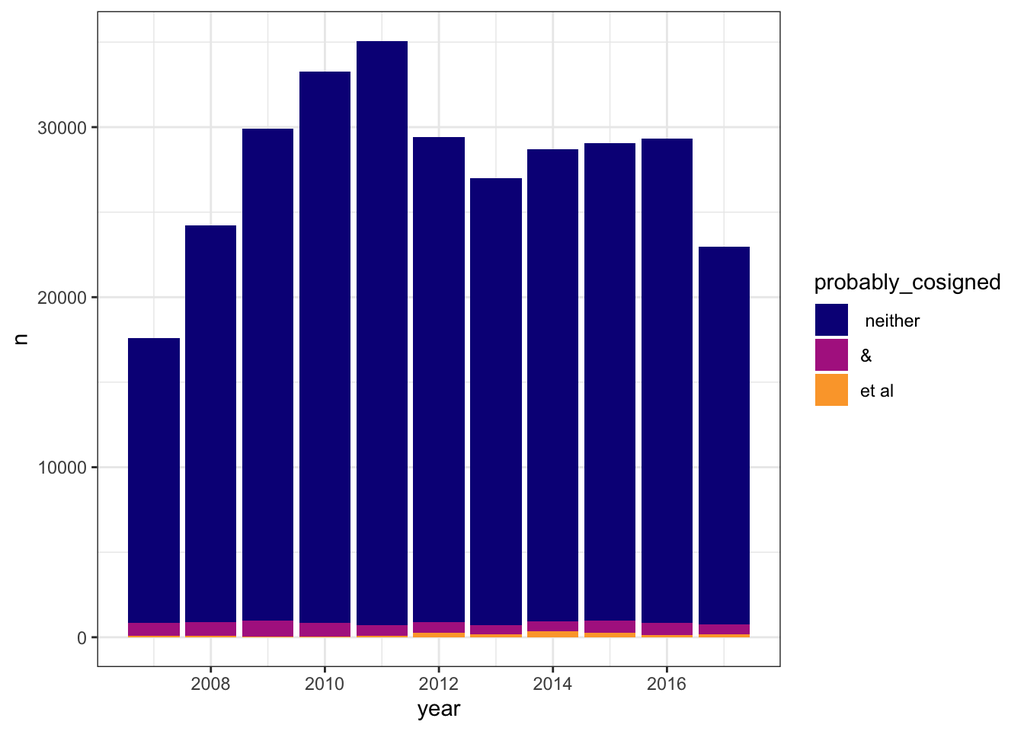

In contrast, the DOD has a very miniscule amount of letters that are cosigned. This is shown in 2010. It was surprising to see the lack of letters to the DOD that were cosigned, but this is indeed a rough estimate, and I suspect that as more observations are implemented, there will be a greater amount of letters that are shown to be cosigned. Letters that are cosigned could show a variety items, whether it’s partnership on rule-making between party members or even bipartisan-styled letters between members of a different party who are working in the same committee.

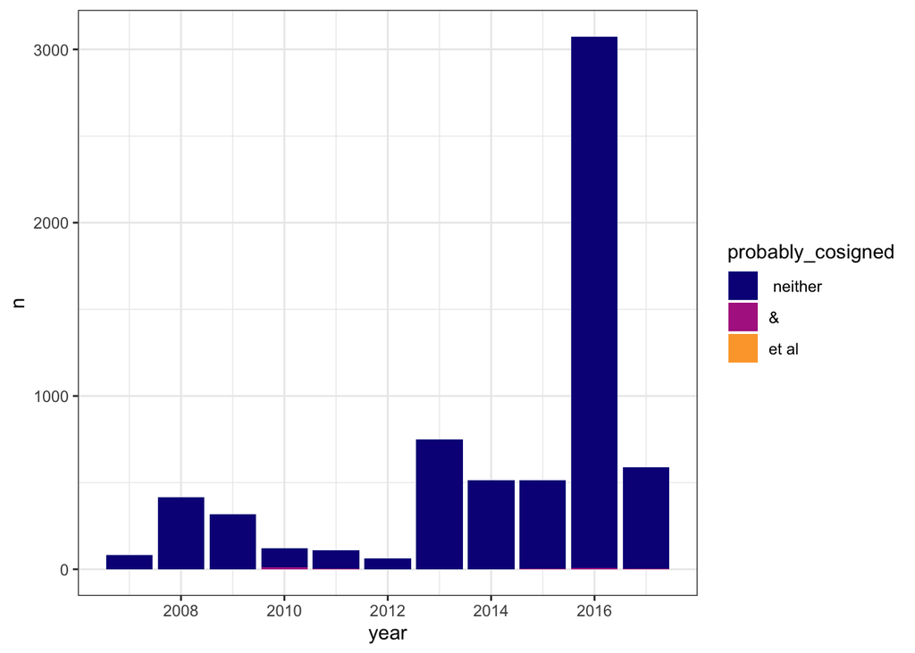

```r
dn %>%
  group_by(ID) %>%
  mutate(probably_cosigned = ifelse(str_detect(SUBJECT, "et al"), "et al",
                                 ifelse(str_detect(SUBJECT, "&"), "&", " neither"))) %>%
  group_by(year, probably_cosigned) %>%
  tally %>%
  ggplot() +
  aes(x = year, y = n, fill = probably_cosigned) +
  geom_col() +
  scale_fill_viridis_d(option = "C", end = .8)
```

# Top Female Legislators who wrote the most letters to the DOD

The following charts show the top female legislators who wrote to the DOD both in general and by committees that are relevant to the DOD such as the armed services, veterans, foreign relations, and appropriations committees. Many of the women who frequently write letters to the DOD represent states that are home to a large veteran population. However, I was surprised at the few amount of letters that were written by female veterans to the DOD. For instance, I expected to see Joni Ernst (R-IA) or Martha McSally (R-AZ) on the list, but they only wrote 24 letters to the DOD.

Further investigation shows that as of 2019, there are four female veterans serving in the House of Representatives-this is considered to be a record high. This inspired representatives Mikie Sherril, Tulsi Gabbard, Elaine Luria, and Chrissy Houlahan to create the House Servicewomen and Women Veterans Congressional Caucus. Curently, there are three female veterans in the senate, Senators Tami Duckworth, Joni Ernst and Martha McSally. I anticipate that as more observations are implemented, especially from 2019, that I will be able to get a better grasp on the influence that female veterans have in the DOD.

Female Legislators who wrote the most letters to DOD

| bioname | party | chamber | cqlabel | committees | yearelected | n |
| --- | --- | --- | --- | --- | --- | --- |
| PELOSI, Nancy | (D) | House | (CA-08) | SPEAKER | 2008 | 35 |
| DAVIS, Susan A. | (D) | House | (CA-53) | ARMED SERVICES\|EDUCATION | 2014 | 31 |
| PELOSI, Nancy | (D) | House | (CA-08) | SPEAKER | 2006 | 24 |
| BALDWIN, Tammy | (D) | Senate | (WI) | APPROPRIATIONS\|BUDGET\|HOMELAND SECURITY\|HEALTH | 2014 | 18 |
| ELLMERS, Renee | (R) | House | (NC-02) | ENERGY | 2014 | 16 |
| HIRONO, Mazie | (D) | Senate | (HI) | ARMED SERVICES\|ENERGY\|SMALL BUSINESS\|VETERANS\|INTELLIGENCE | 2014 | 15 |
| BROWNLEY, Julia | (D) | House | (CA-26) | TRANSPORTATION\|VETERANS | 2014 | 14 |
| TITUS, Alice (Dina) | (D) | House | (NV-01) | TRANSPORTATION\|VETERANS | 2014 | 14 |
| EDWARDS, Donna F. | (D) | House | (MD-04) | TRANSPORTATION\|SCIENCE | 2008 | 13 |
| ADAMS, Alma | (D) | House | (NC-12) | AGRICULTURE\|ECONOMIC\|EDUCATION\|SMALL BUSINESS | 2014 | 11 |
| GILLIBRAND, Kirsten | (D) | Senate | (NY) | AGRICULTURE\|ARMED SERVICES\|ENVIRONMENT\|AGING | 2014 | 11 |
| SLAUGHTER, Louise McIntosh | (D) | House | (NY-25) | RULES | 2014 | 11 |

Female Relevant Committee Members who wrote the most letters to DOD according

| bioname | party | chamber | cqlabel | committees | yearelected | n |
| --- | --- | --- | --- | --- | --- | --- |
| DAVIS, Susan A. | (D) | House | (CA-53) | ARMED SERVICES\|EDUCATION | 2014 | 31 |
| BALDWIN, Tammy | (D) | Senate | (WI) | APPROPRIATIONS\|BUDGET\|HOMELAND SECURITY\|HEALTH | 2014 | 18 |
| HIRONO, Mazie | (D) | Senate | (HI) | ARMED SERVICES\|ENERGY\|SMALL BUSINESS\|VETERANS\|INTELLIGENCE | 2014 | 15 |
| BROWNLEY, Julia | (D) | House | (CA-26) | TRANSPORTATION\|VETERANS | 2014 | 14 |
| TITUS, Alice (Dina) | (D) | House | (NV-01) | TRANSPORTATION\|VETERANS | 2014 | 14 |
| GILLIBRAND, Kirsten | (D) | Senate | (NY) | AGRICULTURE\|ARMED SERVICES\|ENVIRONMENT\|AGING | 2014 | 11 |
| HERRERA BEUTLER, Jaime | (R) | House | (WA-03) | APPROPRIATIONS | 2014 | 10 |
| DAVIS, Susan A. | (D) | House | (CA-53) | ARMED SERVICES\|EDUCATION\|HOUSE ADMINISTRATION\|PRINTING | 2006 | 9 |
| HARTZLER, Vicky | (R) | House | (MO-04) | AGRICULTURE\|ARMED SERVICES | 2016 | 9 |
| WALORSKI, Jackie | (R) | House | (IN-02) | AGRICULTURE\|ARMED SERVICES\|VETERANS | 2014 | 9 |

Note: There are duplicates with members in these charts that will be removed/condensed in another draft.

# By Party

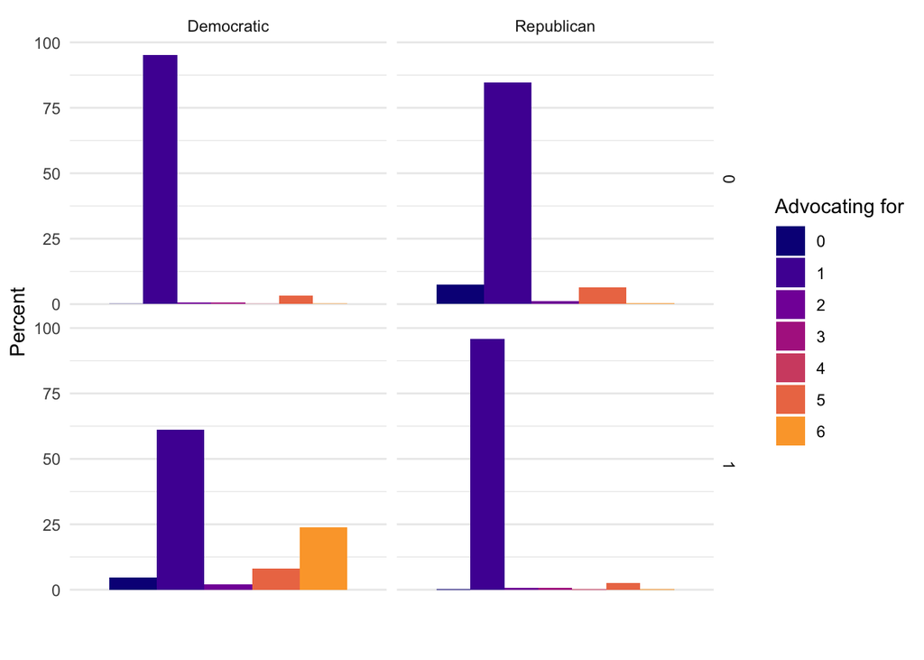

# Bivariate and Multivariate Models

In this draft of the paper, I did not create any variate models, mainly because I was missing a lot of data points for areas that I wanted to look into. In the future, I hope to create models that show the relationship between gender and letters written, non-constituent and constituent letters written in the DOD, as well as the contrast of political parties in the collection of letters that the DOD receives. Exploring these pieces may help with looking more closely into which party advocates more for constituents/businesses in the DOD, which party writes to the DOD in general, as well as if there is any gender bias when it comes to constituents who write letters to their congressmember, especially if the congressmember is a veteran and female.

# Summary

# Limitations throughout the Independent Study

Throughout the course of this independent study, there were a few limitations I faced. First of all, Google has increased their security as of November 2019, which means we no longer have access to many of the googlesheets packages we use in order to pull in data and organize it in an appropriate manner. Consequently, this means that a large majority of our data and observations have not been updated or accounted for in the last 6 months. Thus, the thousands of letters that I handcoded, as well as the the dates that I had fixed within the DOD dataset were not able to be used in this first draft of the paper. Furthermore, we are still waiting to receive logs from several DOD agencies which would further allow my analysis to be complete. Many of the agencies I handcoded primarily were agencies that deal with civilians or veterans and I predict that as we receive logs from the Air Force and the Defense Logistics agency, we may see more interesting cases regarding the relationship between businesses and the DOD. Lastly, a lot of my analysis is still yet to be done, since I had issues with pieces of code not working as well as identifying characteristics (for instance, gender) missing with some members of congress. There are also some duplicates in the data set that I am working on fixing/evaluating as to why they are showing up.

# Future ideas to explore with this paper

In the future, I hope to continue my exploration with this topic by analyzing some different aspects to help evaluate the overlying question of how Department of Defense agencies interact with constituents and legislators. One major category I’d like to investigate is demographics, both within members of congress as well as within constituents who write to their congressmember. I am interested in exploring how a congressmember’s veteran status can influence their constituent relationship. Specifically, I am interested in seeing how gender, specifically a female veteran congressmember can influence the bills that she introduces in congress as well as the types of policies that she may support as a result of her Active Duty experience or experience from dealing with veteran/active duty constituents. A method that can allow me to also investigate the demographic relationship with the DOD is by doing constituent coding as well as looking closely at the different congressional districts in the US, specifically the districts that have military bases or a large active duty/population. Moreover, I am interested in looking at bipartisan relationships within legislators who actively work with the DOD as well as take a further look at the policies and bills that are implemented within the different policy committees within the house and the senate. I am interested in looking into members who contact the DOD more, relative to other agencies as well and potentially what the reasoning may be behing that. Lastly, I am also curious about the relationship between legislators and businesses and I’m curious to see if in the future I can investigate certain companies that write to congressmembers and what their motive is behind the correspondence. An appendix, with extra figures, letters, and a FOIA request will also be added in a future draft of this paper.

# References

Costa, Mia (2020). Citizen Evaluations of Legislator–Constituent Communication.  
*British Journal of Political Science*.

Fenno, Richard F. (1977). U.S. House Members in Their Constituencies: An Exploration. *American Political Science Review*, 883-917.

Fenno, Richard F. (2013). *The Challenge of Congressional Representation.* Harvard  
University Press, 138-184.

Jordan, Amos A, William J. Taylor, Jr, and Michael J. Mazar (2009). American  
National Security, Johns Hopkins University Press.

Judge-Lord, Devin, Eleanor Neff Powell, and Justin Grimmer (2020). Campaign  
Contributions and Bureaucratic Oversight: A Case Study of the Federal Energy  
Regulatory Commission. Unpublished Working Paper. Presented at the Accountability and Public Policy Conference 2019.

Kingdon, John W (1977). Models of Legislative Voting. *The Journal of Politics (39)*, 563–595.

Laurance, Edward J (1976). The Changing Role of Congress in Defense Policy-Making. *The Journal of Conflict Resolution (20)*, 213–253.

Lindsay, James M., and Randall B. Ripley (1992). Foreign and Defense Policy in Congress: A Research Agenda for the 1990s. *Legislative Studies Quarterly*, 417–449.

Lindsay, James M., and Randall B. Ripley (1994). How Congress Influences Foreign and Defense Policy. *Bulletin of the American Academy of Arts and Sciences, 47*, 7–32.

Lowande, Kenneth (2018). Politicization and Responsiveness in Executive Agencies.  
*Journal of Politics*.

Lowande, Kenneth (2018). Who Polices the Administrative State? American Political  
Science Review, 874–890.

McCarty, Nolan, Keith T. Poole, and Howard Rosenthal (2006). *Polarized America: The dance of ideology and unequal riches*, MIT Press.

Oleszek, Walter J (2013). *Congressional Procedures and the Policy Process*,  
Congressional Quarterly Press.

Poole, Keith T. and Howard Rosenthal (2007) *Ideology and Congress*, Transaction  
Publishers.

Powell, Eleanor Neff and Justin Grimmer (2016). Money in Exile: Campaign Contributions and Committee Access. *The Journal of Politics 78(4)*, 974–88.

Reif, Kingston (2017). Congress Rewrites Missile Defense Policy. *Arms Control Today, 47*, 40–42.

Ritchie, Melinda N (2017). Back-Channel Representation: A Study of the Strategic Communication of Senators with the US Department of Labor. *Journal of Politics*.

Ritchie, M.N. and You, H.Y (2019). Legislators as Lobbyists. Legislative Studies  
Quarterly, 65-95.

Rohde, David W (1991). *Parties and leaders in the post-reform House of Representatives.* University of Chicago Press.

US Census Bureau (2018). Veterans Statistics. *The United States Census Bureau*.  
https://www.census.gov/library/visualizations/2015/comm/veterans-statistics.html. Date accessed: February 14, 2020.